# IPV Measurement Memo

# 1 Summary

- Both the continuous and the binary measure of violence yield unbiased estimates of the true treatment effect, but of different estimands:
  - The binary measure produces an unbiased estimate of the difference in the proportion who are experiencing any violence over the recall period.
  - The continuous measure produces an unbiased estimate of the mean difference in number and frequency of violent acts experienced over the recall period.
- In simple simulations for a single act of violence (e.g. slapping) the continuous measure dominates the binary in terms of power except in the limit where the effect is very small (almost zero) or very large (almost complete cessation) in which case they are about equal.
- In more complex simulations where we model 10 different violent acts, the continuous still dominates when there is a constant/homogeneous effect across all acts.
- However, when we allow for heterogeneity/effects to vary by act, there are instances in which the binary measure is higher powered. These arise in cases in which there is a divergence in effects, where some acts are positively affected and some are negatively affected, or when effects are concentrated at the low end of the frequency distribution.

# 2 Introduction

Most evaluations of interventions to reduce intimate partner violence rely on some form of the Conflict Tactics Scale (CTS)[^1] to quantify a participant’s experience of violence. This instrument attempts to dissociate acts/behaviors from their personal or social meaning as “violence” by asking the respondent to report the frequency that they have experienced specific acts over a defined recall period.

Table 1. Example of questions adapted from CTS for measuring violence.

| In the past 12 months, how often has your partner… | Never | Once | A few times | Many times |
| --- | --- | --- | --- | --- |
| slapped you or thrown something at you that could hurt you? | 0 | 1 | 2 | 3 |
| pushed you or shoved you or pulled your hair? | 0 | 1 | 2 | 3 |
| hit you with his fist or with something else that could hurt you? | 0 | 1 | 2 | 3 |
| kicked you, dragged you or beaten you up? | 0 | 1 | 2 | 3 |
| choked or burnt you on purpose? | 0 | 1 | 2 | 3 |
| threatened you with or actually used a gun, knife or other weapon against you? | 0 | 1 | 2 | 3 |

Traditionally, the researcher collapses the answers to these questions into a single binary outcome representing whether the respondent reports any act of violence during the recall period and uses this as the basis for statistical inference. We believe this outcome is more of a historical consequence rather than the optimal analytical choice from a research perspective. In this paper, we evaluate this coding strategy in terms of its efficiency –i.e. the consequences in terms of the statistical power and precision for answering substantive research questions– as well as its implications for theory and mechanism of violence reduction. We do this through a simulation study.

# 3 Description of simulations

## 3.1 Single act simulation

We begin by assuming a model for violence ($Y$), specifically we assume that it may be modeled as Poisson process governed by a common parameter $\lambda$ that represents the average rate of violence during the defined recall period.
$$Y \sim \text{Poisson}(\lambda)$$
We choose this model as a starting point because it is relatively straightforward while still matching the empirical data distribution quite well. It also makes some sense as, in probability theory, the Poisson distribution generally describes the probability of observing $k$ events in a finite time period (e.g. in our case, the probability of experincing $k$ instances of a single act of violence over the recall period). Using `R` we can simulate random Poisson observations for a study population of size $N$.

[figure not shown]

Next, we simulate a hypothetical randomized intervention study by constructing two counterfactual outcomes representing, for each individual, their value of $Y$ if given the intervention and their value of $Y$ if not given the intervention.
$$Y^{z} \begin{cases}
Y^0 & \text{counterfactual number of violent events under no intervention} \\
Y^1 & \text{counterfactual number of violent events under intervention}
\end{cases}$$
We simulate $Y^0$ as a Poisson random variable with $\lambda = 0.3$, representing a baseline frequency of violence that matches that of our empirical sample. We then calculate $Y^1$ for each individual as their counterfactual value under no intervention plus the effect of the intervention, i.e.
$$Y^1 = Y^0 + \tau$$
We consider possible values of $\tau$ between -0.3 (complete cessation for all) and 0 (no effect for any individual).

We define two different coding strategies for the violent event outcomes. The first strategy is to collapse $Y^{z}$ into a single binary measure, i.e.
$$Y^{z}_{binary} =
\begin{cases}
0 & \text{if } Y^{z} = 0 \\
1 & \text{if } Y^{z} \geq 1 \\
\end{cases}$$
The second is to leave it as a continuous measure
$$Y^{z}_{continuous} = Y^{z}$$

These simulated individuals are then randomly assigned to either an intervention $Z=1$ or no intervention condition $Z=0$ that determines which counterfactual outcome they reveal (i.e. $Y^{1}_{binary}$ vs. $Y^{0}_{binary}$ and $Y^{1}_{continuous}$ vs. $Y^{0}_{continuous}$) and finally we estimate treatment effect as we would in the real world using regressions of the form.

$$\text{E}[Y \mid Z] = \beta_0 + \beta_1 Z$$

We do this using the `DeclareDesign`[^2] package in `R` which provides a robust library of functions for simulating complex research designs.

## 3.2 Multiple act simulation

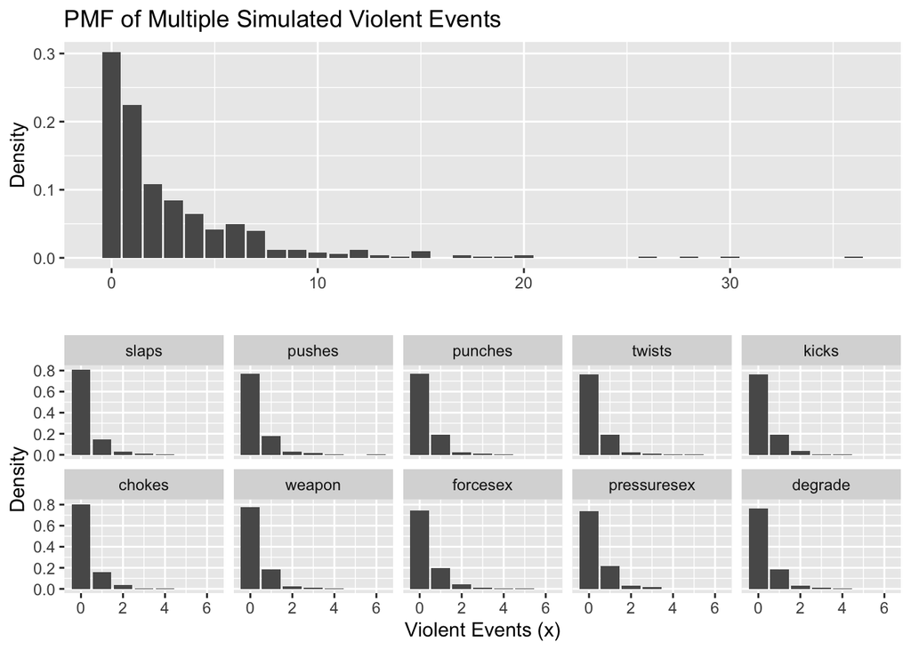

The rest of the simulation proceeds as described for the single act, except we can now investigate more complex treatment effect patterns. For the purposes of this study we chose to simulate the following scenarios:

1. `constant` - a constant/homogeneous treatment effect across all 10 acts
2. `physical_only` - moderate reductions in all physical violence variables, but no reduction in sexual violence.
3. `sexual_only` - moderate reductions in all sexual violence variables, but no reduction in physical violence.
4. `moderate_only` - reduction in only slapping and pushing, all other acts are unaffected.
5. `divergence` - large reduction in slapping and pushing but increases in more severe violence and small uptick in sexual violence.

# 4 Results

## 4.1 Single act simulation

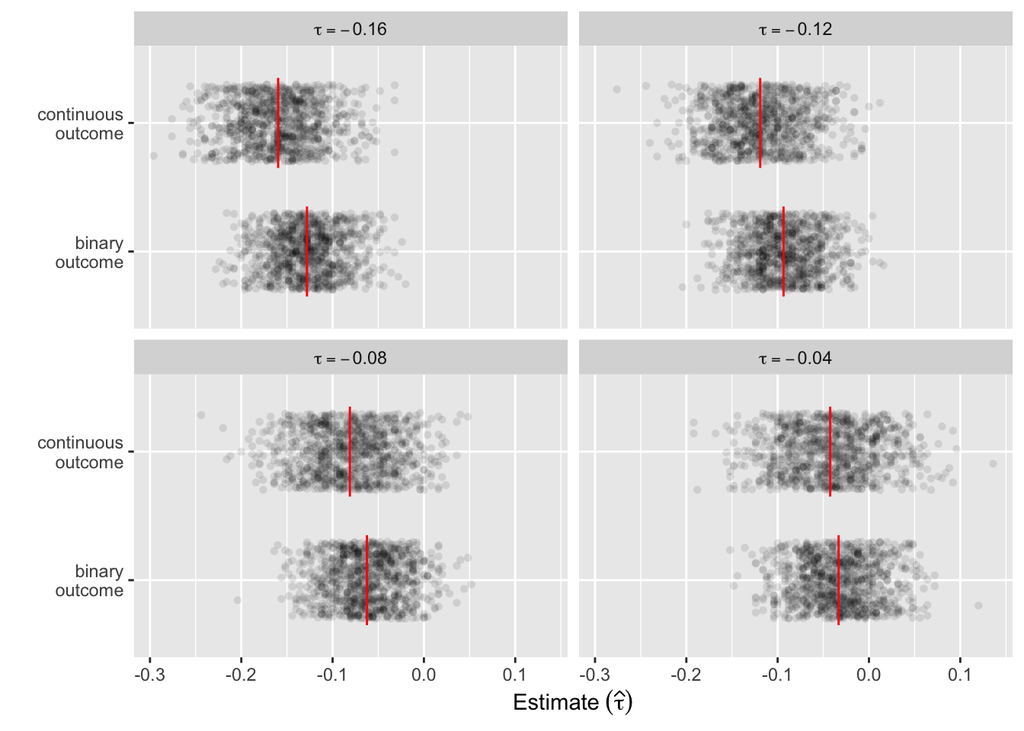

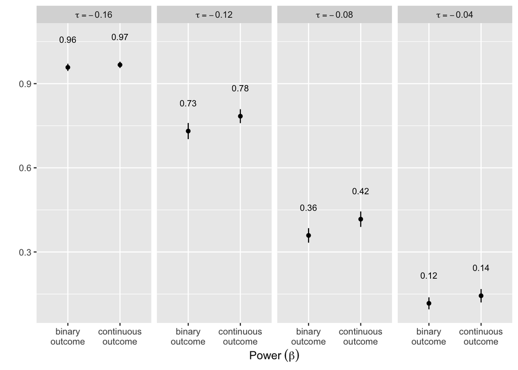

## 4.2 Multiple act simulation

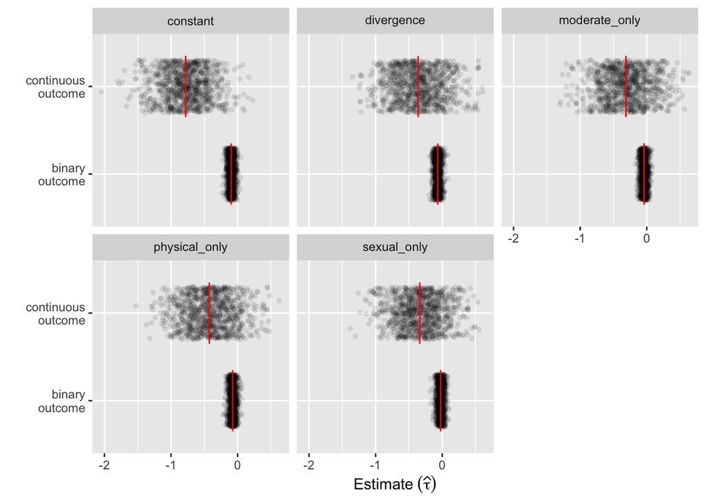

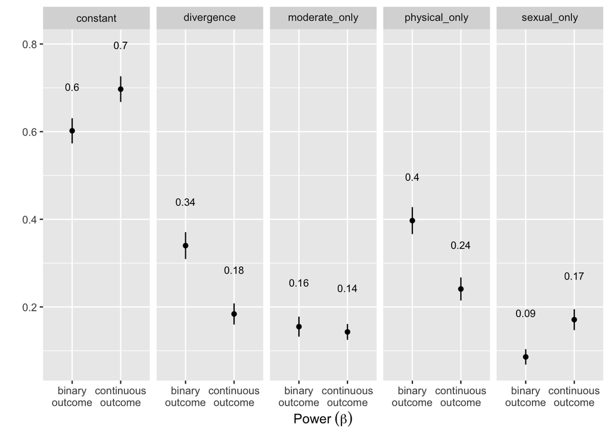

[^1]: Straus, M. A., Hamby, S. L., Boney-McCoy, S., & Sugarman, D. B. (1996). The revised conflict tactics scales (CTS2) development and preliminary psychometric data. Journal of family issues, 17(3), 283-316.
[^2]: https://declaredesign.org